# Tanager Evolution Project Notes

### Step 14: What do the coefficients mean?

In the last step, we were able to reconstruct what the splines were through the use of a basis (wavelengths from 300-700 nm) and spline coefficients. We were able to deduce that the intercept was the key component to maintaining the biological meaning to our splines if ran through BEAST. Here we attempt to identify the function of the different spline coefficients through the case study of TanCyo.

```r
# Taking our matrix created from bSpline and turning it into a matrix object
basis_spline_matrix <- matrix(bspline_matrix_bSpline, nrow = 401, ncol = 38)

# Turning our TanCyo reflectance coefficients into a 38x1 matrix
spline_coefficient_matrix <- matrix(TanCyo$reflectance_coef[2:39])

# Multiplying the matrices using the matrix multiplication operator (%*%)
spline_reconstruction <- basis_spline_matrix %*% spline_coefficient_matrix

# Verification that this matrix multiplication is how we are getting our curves through the spline functions (does not include the addition of the intercept coefficient here although if the answer is TRUE, adding the intercept to both objects will still produce a TRUE output)
identical(c(spline_reconstruction), coef_spline_reconstruction$reflectance)
```

```
## [1] TRUE
```

IT’S JUST MATRIX MULTIPLICATION, I HAVE NO IDEA WHAT THE BIOLOGICAL INTERPRETATION OF THE COEFFICIENTS ARE BUT I DOUBT IT IS USEFUL TO TRY AND UNDERSTAND THEM OR TAKE MEANS OF THEM ETC. The real question at this stage is to identify what the basis matrix represents for our system, as it is not clear as to what it could represent. Are the spline coefficients just a scalar to shape the curve?

### Step 15: What do spline coefficients do? What does the basis matrix mean?

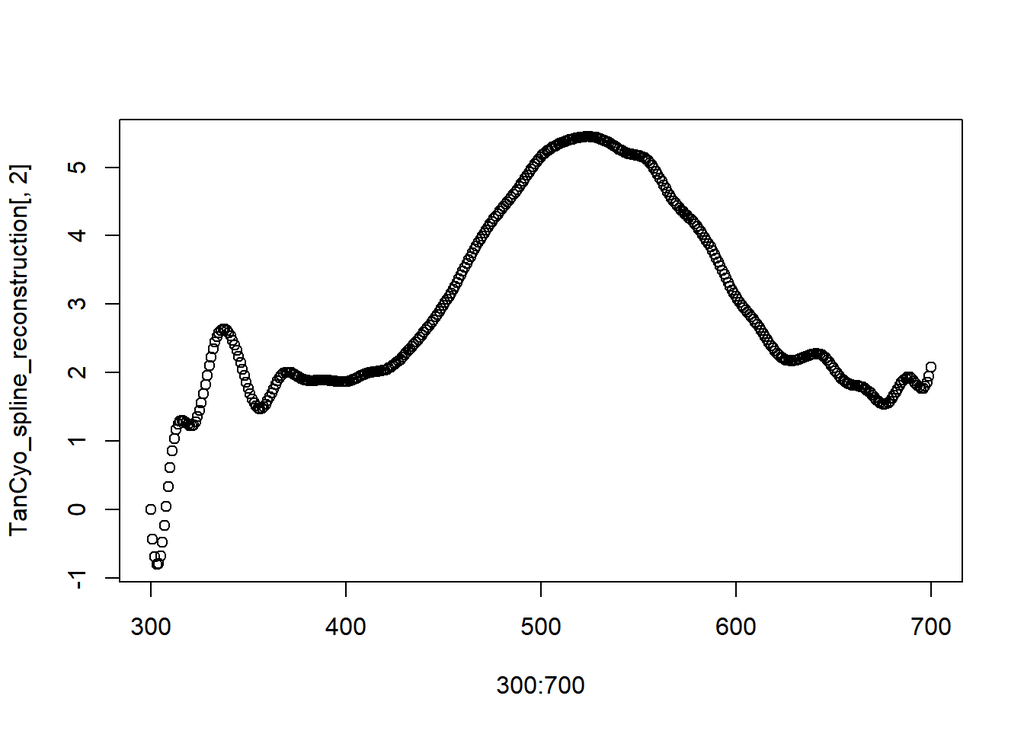

```r
TanCyo_spline_reconstruction <- cbind(300:700,predict(bspline_matrix_bSpline, coef = as.numeric(c(TanCyo_spline_coefficients[2:39]))))


plot(300:700, TanCyo_spline_reconstruction[,2])
```

```r
TanCyo_adjusted_coefficients <- TanCyo_spline_coefficients[2:39]
print(TanCyo_spline_coefficients[21])
```

```
## bs(wl, df = 38)20
##              5.37
```

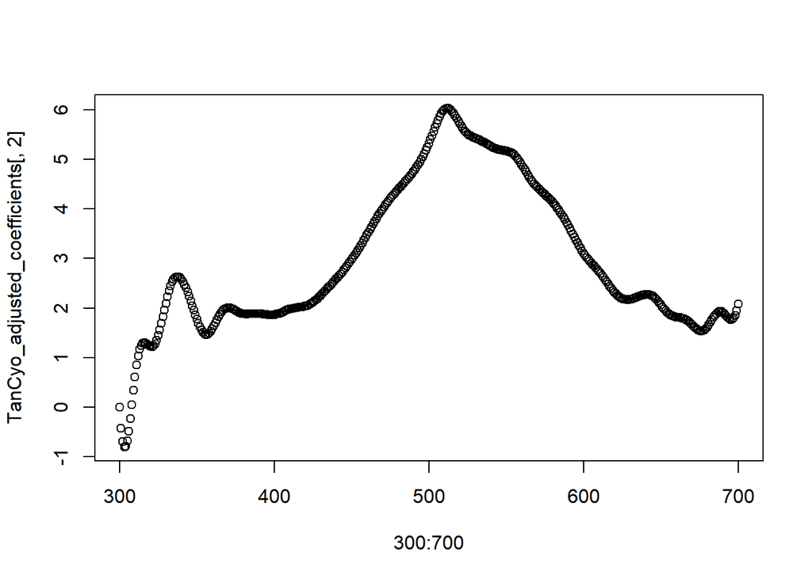

```r
TanCyo_adjusted_coefficients[20] <- TanCyo_adjusted_coefficients[20]+1

TanCyo_adjusted_coefficients <- cbind(300:700, predict(bspline_matrix_bSpline, coef = TanCyo_adjusted_coefficients))
plot(300:700, TanCyo_adjusted_coefficients[,2])
```

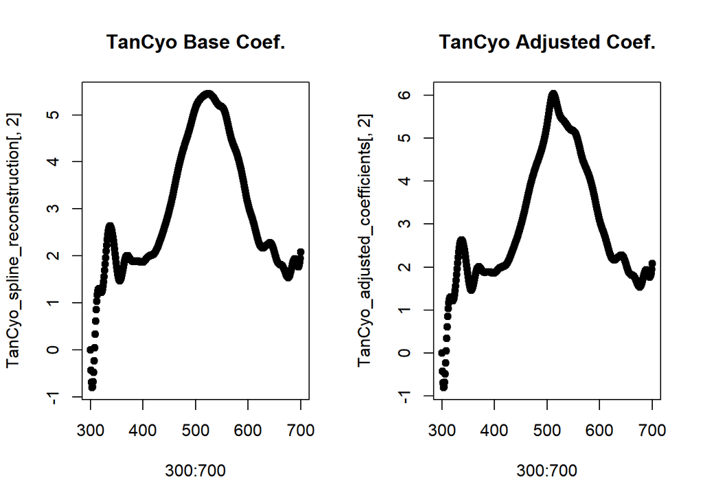

```r
par(mfrow=c(1,2))
plot(300:700, TanCyo_spline_reconstruction[,2], pch = 19, main = "TanCyo Base Coef.")
plot(300:700, TanCyo_adjusted_coefficients[,2], pch = 19, main = "TanCyo Adjusted Coef.")
```

```r
par(mfrow=c(1,1))

spline_coef_comparison <- cbind(predict(bspline_matrix_bSpline, coef = (c(TanCyo_spline_coefficients[2:39]))), c(TanCyo_adjusted_coefficients[,2]))
spline_coef_comparison <- cbind(300:700, spline_coef_comparison)
```

I do not think the basis matrix or the spline coefficients have any inherit biological information.

### Step 16: Comparing our splines for mean reflectance data and mean spline coefficients

```r
mean_reflectance_values <- NULL
for (i in 1:401){

  x <- i
  mean_reflectance_values[i] <- mean(tanData_filtered_wowl[,x])

}

random_number <- round(runif(1, min = 1, max = 401), 0)
mean_reflectance_values[random_number] == mean(tanData_filtered_wowl[,random_number])
```

```
## [1] TRUE
```

```
## wavelengths found in column 1
```

```
## processing options applied:
## Negative value correction: converted negative values to zero
```

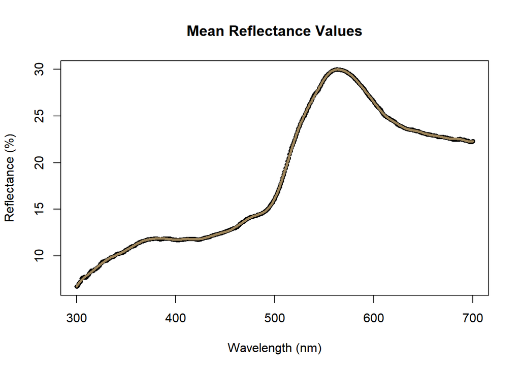

```r
mean_reflectance_values <- cbind(300:700, mean_reflectance_values)

spline_fit_mean_reflectance <- gls(mean_reflectance_values[,2] ~ bs(mean_reflectance_values[,1], df = 38), correlation = corAR1(form = ~1))

mean_reflectance_values <- cbind(mean_reflectance_values, predict(spline_fit_mean_reflectance))

colnames(mean_reflectance_values) <- c("wl", "reflectance", "spline_fit")

plot(x = 300:700, y = mean_reflectance_values[,"reflectance"], xlab = "Wavelength (nm)", ylab = "Reflectance (%)", main = "Mean Reflectance Values", pch = 19, cex = 0.75)
lines(x = 300:700, y = mean_reflectance_values[,"spline_fit"], col = spec2rgb(procspec(as.rspec(mean_reflectance_values), fixneg = "zero")), lwd = 3)
```

```r
mean_spline_coefficients <- NULL
for (i in 1:39){

  x <- i+1

  mean_spline_coefficients[i] <- mean(spline_coef_data[,x])

}

random_number <- round(runif(1, min = 1, max = 39), 0)
mean_spline_coefficients[random_number] == mean(spline_coef_data[,random_number+1])
```

```
## [1] TRUE
```

```
## wavelengths found in column 1
## processing options applied:
## Negative value correction: converted negative values to zero
```

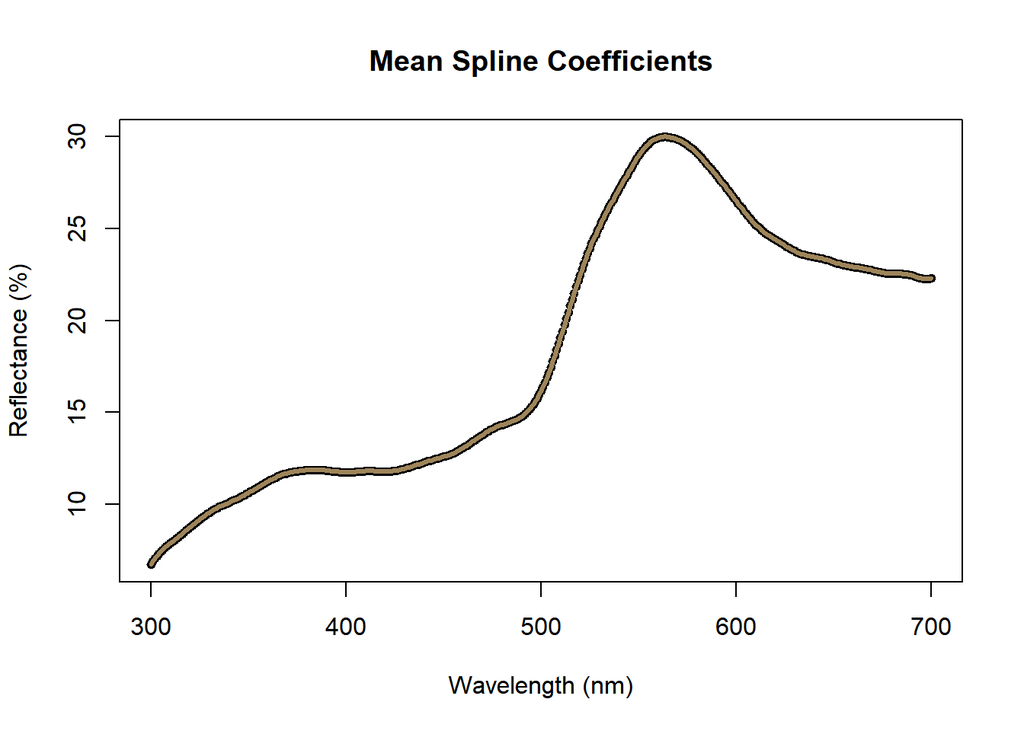

```r
mean_spline_coefficients_output <- cbind(300:700, predict(bspline_matrix_bSpline, coef = mean_spline_coefficients[2:39]))

colnames(mean_spline_coefficients_output) <- c("wl", "reflectance")

mean_spline_coefficients_output[,2] <- mean_spline_coefficients_output[,2] + mean_spline_coefficients[1]

plot(x = 300:700, y = mean_spline_coefficients_output[,"reflectance"], main = "Mean Spline Coefficients", xlab = "Wavelength (nm)", ylab = "Reflectance (%)", pch = 19, cex = 0.75)
lines(x = 300:700, y = mean_spline_coefficients_output[,"reflectance"], col = spec2rgb(procspec(as.rspec(mean_spline_coefficients_output), fixneg = "zero")), lwd = 3)
```

```r
spec2rgb(procspec(as.rspec(mean_reflectance_values), fixneg = "zero"))
```

```
## wavelengths found in column 1
## processing options applied:
## Negative value correction: converted negative values to zero
```

```
## reflectance  spline_fit
## "#9E855AFF" "#9E855AFF"
```

```r
spec2rgb(procspec(as.rspec(mean_spline_coefficients_output), fixneg = "zero"))
```

```
## wavelengths found in column 1
## processing options applied:
## Negative value correction: converted negative values to zero
```

```
## reflectance
## "#9E855AFF"
```

```r
par(mfrow=c(1,2))

plot(x = 300:700, y = mean_reflectance_values[,"reflectance"], xlab = "Wavelength (nm)", ylab = "Reflectance (%)", main = "Mean Reflectance Values", pch = 19, cex = 0.75)
lines(x = 300:700, y = mean_reflectance_values[,"spline_fit"], col = spec2rgb(procspec(as.rspec(mean_reflectance_values), fixneg = "zero")), lwd = 3)
```

```
## wavelengths found in column 1
## processing options applied:
## Negative value correction: converted negative values to zero
```

```
## wavelengths found in column 1
## processing options applied:
## Negative value correction: converted negative values to zero
```

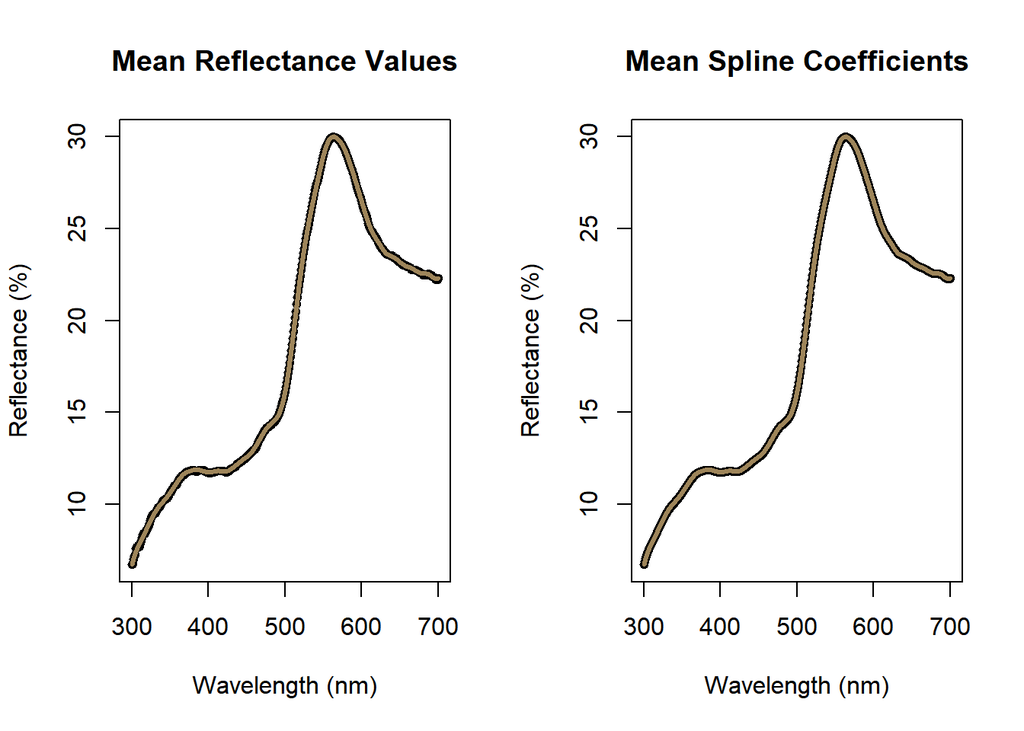

```r
plot(x = 300:700, y = mean_spline_coefficients_output[,"reflectance"], main = "Mean Spline Coefficients", xlab = "Wavelength (nm)", ylab = "Reflectance (%)", pch = 19, cex = 0.75)
lines(x = 300:700, y = mean_spline_coefficients_output[,"reflectance"], col = spec2rgb(procspec(as.rspec(mean_spline_coefficients_output), fixneg = "zero")), lwd = 3)
```

```r
par(mfrow=c(1,1))
```